# Statistics for Data Science with `R`

# Gamma Examples

```r
require(ggplot2)
require(dplyr)
require(qdata)
```

## Example: Boiling time

### Data description

In an attempt to resolve a domestic dispute about which of two `pan`s was the quicker pan for cooking, the following data were obtained. Various measured `volume`s (pints) of cold water were put into each pan and geared using the same setting of the cooker. The response variable was the `time` in minutes until the water boiled.

`time` is a non-negative variable; the gamma distribution is then probabily more appropriate than gaussian distribution. Finally, keep in mind that with glm 6 observations are few, since most of statistical results about GLM are asymptotic.

### Data loading

```r
data(boiling)
boiling
```

```
## # A tibble: 6 x 3
##    time    pan volume
##   <dbl> <fctr>  <dbl>
## 1  4.65      A      1
## 2  9.75      A      3
## 3 15.05      A      5
## 4  4.75      B      1
## 5 10.15      B      3
## 6 15.50      B      5
```

### Descriptives

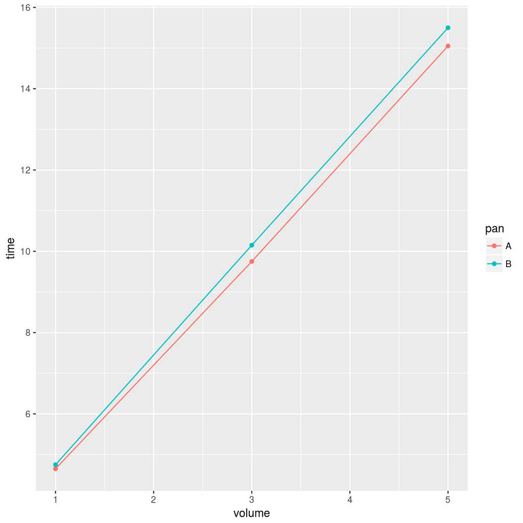

time Vs. volume plot for the 2 pans

```r
ggp <- ggplot(data = boiling,mapping = aes(x = volume, y = time)) +
  geom_point(mapping = aes(colour=pan)) +
  geom_line(mapping = aes(colour=pan))
print(ggp)
```

A difference in slope appears between the two lines, but the difference is not too big. We want to test if the difference is really significant.

### Models and inference

Initially, a simple linear model is tried; only main effects are estimated. Note that a general linear model with Gaussian error and Identity link is actually a simple linear model.

```r
fm1 <- glm(time ~ volume + pan - 1, data = boiling, family = gaussian)
summary(fm1)
```

```
##
## Call:
## glm(formula = time ~ volume + pan - 1, family = gaussian, data = boiling)
##
## Deviance Residuals:
##        1         2         3         4         5         6
##  0.12083  -0.06667  -0.05417  -0.09583   0.01667   0.07917
##
## Coefficients:
##        Estimate Std. Error t value Pr(>|t|)
## volume  2.64375    0.02803   94.32 2.63e-06 ***
## panA    1.88542    0.10611   17.77 0.000389 ***
## panB    2.20208    0.10611   20.75 0.000245 ***
## ---
## Signif. codes:  0 '***' 0.001 '**' 0.01 '*' 0.05 '.' 0.1 ' ' 1
##
## (Dispersion parameter for gaussian family taken to be 0.01256944)
##
##     Null deviance: 709.022500  on 6  degrees of freedom
## Residual deviance:   0.037708  on 3  degrees of freedom
## AIC: -5.3905
##
## Number of Fisher Scoring iterations: 2
```

All parameters are clearly significant. We may want to check for a difference in slope between pots.

Now we then estimate a model with an additional parameter to model difference in slopes:

```r
fm2 <- glm(time ~ pan + volume:pan - 1, data = boiling, family = gaussian)
summary(fm2)
```

```
##
## Call:
## glm(formula = time ~ pan + volume:pan - 1, family = gaussian,
##     data = boiling)
##
## Deviance Residuals:
##         1          2          3          4          5          6
##  0.033333  -0.066667   0.033333  -0.008333   0.016667  -0.008333
##
## Coefficients:
##             Estimate Std. Error t value Pr(>|t|)
## panA         2.01667    0.07187   28.06  0.00127 **
## panB         2.07083    0.07187   28.82  0.00120 **
## panA:volume  2.60000    0.02104  123.57 6.55e-05 ***
## panB:volume  2.68750    0.02104  127.73 6.13e-05 ***
## ---
## Signif. codes:  0 '***' 0.001 '**' 0.01 '*' 0.05 '.' 0.1 ' ' 1
##
## (Dispersion parameter for gaussian family taken to be 0.003541667)
##
##     Null deviance: 7.0902e+02  on 6  degrees of freedom
## Residual deviance: 7.0833e-03  on 2  degrees of freedom
## AIC: -13.423
##
## Number of Fisher Scoring iterations: 2
```

Actually, the model contains two distinct linear models: one for `panA`, and one for `panB`.  
Now a test on significancy of difference is performed (note that the test distribution in this case is F, because $\phi$, dispersion parameter, is estimated).

```r
anova(fm1,fm2,test="F")
```

```
## Analysis of Deviance Table
##
## Model 1: time ~ volume + pan - 1
## Model 2: time ~ pan + volume:pan - 1
##   Resid. Df Resid. Dev Df Deviance      F Pr(>F)
## 1         3   0.037708
## 2         2   0.007083  1 0.030625 8.6471 0.0988 .
## ---
## Signif. codes:  0 '***' 0.001 '**' 0.01 '*' 0.05 '.' 0.1 ' ' 1
```

Note that in this case of normal model, the `test=F` option is perfectly appropriate with theory of linear models (LM).

A difference in slope only marginally exists.  
However, this model could be unsatisfactory in two respects:

- boiling time cannot be negative
- the variance of boiling time might be expected to increase with its expectation;

The natural candidate for these problems is the gamma distibution, as it respects the increasing relation between mean and variance as shown in the next graphical example.

Next plot produce a comparison between Gaussian and Gamma means and variances while means vary.

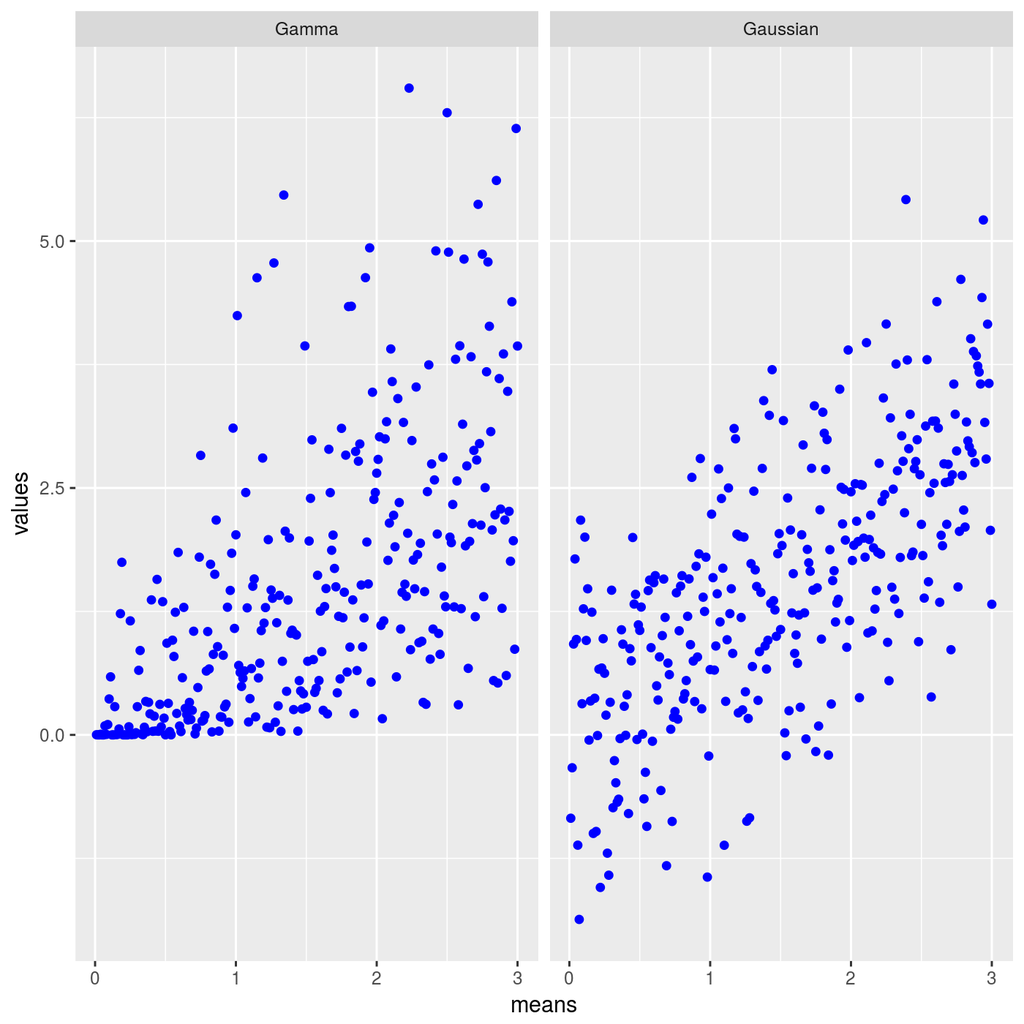

How dispersion varies with means for Gaussian models and Gamma models

```r
set.seed(2000)
means <- (1:300)/100
x1 <- apply(as.matrix(means),MARGIN=1,FUN=function(x){rnorm(1,mean=x)})
x2 <- apply(as.matrix(means),MARGIN=1,FUN=function(x){rgamma(1,shape=x, scale = 1)})
ds <- data.frame(means=rep(means, 2), values=c(x1,x2), distribution=rep(c("Gaussian","Gamma"), each=300))

ggp <- ggplot(data = ds, mapping = aes(x=means, y = values)) +
  geom_point(colour="blue") +
  facet_wrap(facets = ~distribution)
print(ggp)

rm(means,x1,x2,ds)
```

The plot just created compare points arising from linear models with the same deterministic component, but the former with Gamma error distribution, while the latter with Gaussian error distribution and identity link. Two things are evident:

- Gaussian linear model can return values less than zero, whereas Gamma model does not.
- Gaussian linear model has a substantially constant variability while Gamma linear model is clearly heteroscedastic.

Now, a model from Gamma family and identity link will be estimated on data:

```r
fm3 <- glm(time ~ pan + volume:pan - 1, data = boiling,
          family = Gamma(link = "identity"))
summary(fm3)
```

```
##
## Call:
## glm(formula = time ~ pan + volume:pan - 1, family = Gamma(link = "identity"),
##     data = boiling)
##
## Deviance Residuals:
##          1           2           3           4           5           6
##  0.0014711  -0.0062328   0.0047405  -0.0003524   0.0015024  -0.0011512
##
## Coefficients:
##             Estimate Std. Error t value Pr(>|t|)
## panA         2.05924    0.03944   52.21 0.000367 ***
## panB         2.06013    0.04047   50.91 0.000386 ***
## panA:volume  2.58393    0.01947  132.73 5.68e-05 ***
## panB:volume  2.69155    0.02010  133.88 5.58e-05 ***
## ---
## Signif. codes:  0 '***' 0.001 '**' 0.01 '*' 0.05 '.' 0.1 ' ' 1
##
## (Dispersion parameter for Gamma family taken to be 3.355215e-05)
##
##     Null deviance:        NaN  on 6  degrees of freedom
## Residual deviance: 6.7191e-05  on 2  degrees of freedom
## AIC: -15.087
##
## Number of Fisher Scoring iterations: 3
```

Comparing AIC stats

```r
fm2$aic ; fm3$aic
```

```
## [1] -13.42336
```

```
## [1] -15.08717
```

Gamma model results slightly better than Gaussian one.

Now let us check on significancy of differences between the two pans:

```r
fm3a <- glm(time ~ pan + volume + volume:pan, data = boiling,
         family = Gamma(link = "identity"))
summary(fm3a)
```

```
##
## Call:
## glm(formula = time ~ pan + volume + volume:pan, family = Gamma(link = "identity"),
##     data = boiling)
##
## Deviance Residuals:
##          1           2           3           4           5           6
##  0.0014711  -0.0062328   0.0047405  -0.0003524   0.0015024  -0.0011512
##
## Coefficients:
##              Estimate Std. Error t value Pr(>|t|)
## (Intercept) 2.0592378  0.0394407  52.211 0.000367 ***
## panB        0.0008908  0.0565096   0.016 0.988854
## volume      2.5839284  0.0194681 132.726 5.68e-05 ***
## panB:volume 0.1076174  0.0279858   3.845 0.061457 .
## ---
## Signif. codes:  0 '***' 0.001 '**' 0.01 '*' 0.05 '.' 0.1 ' ' 1
##
## (Dispersion parameter for Gamma family taken to be 3.355215e-05)
##
##     Null deviance: 1.3170e+00  on 5  degrees of freedom
## Residual deviance: 6.7191e-05  on 2  degrees of freedom
## AIC: -15.087
##
## Number of Fisher Scoring iterations: 3
```

```r
fm4 <- glm(time ~ pan + volume, data = boiling, family = Gamma(link = "identity"))
summary(fm4)
```

```
##
## Call:
## glm(formula = time ~ pan + volume, family = Gamma(link = "identity"),
##     data = boiling)
##
## Deviance Residuals:
##         1          2          3          4          5          6
##  0.008464  -0.013635  -0.007106  -0.007675   0.008926   0.010837
##
## Coefficients:
##             Estimate Std. Error t value Pr(>|t|)
## (Intercept)  1.97422    0.07684  25.691 0.000129 ***
## panB         0.17578    0.07937   2.215 0.113615
## volume       2.63665    0.03310  79.658 4.36e-06 ***
## ---
## Signif. codes:  0 '***' 0.001 '**' 0.01 '*' 0.05 '.' 0.1 ' ' 1
##
## (Dispersion parameter for Gamma family taken to be 0.0001878572)
##
##     Null deviance: 1.31704187  on 5  degrees of freedom
## Residual deviance: 0.00056406  on 3  degrees of freedom
## AIC: -4.3213
##
## Number of Fisher Scoring iterations: 3
```

```r
anova(fm3a,fm4,test="F")
```

```
## Analysis of Deviance Table
##
## Model 1: time ~ pan + volume + volume:pan
## Model 2: time ~ pan + volume
##   Resid. Df Resid. Dev Df    Deviance      F  Pr(>F)
## 1         2 0.00006719
## 2         3 0.00056406 -1 -0.00049687 14.809 0.06138 .
## ---
## Signif. codes:  0 '***' 0.001 '**' 0.01 '*' 0.05 '.' 0.1 ' ' 1
```

The above test checks if the difference in slope between the two pans is significant. The test distribution is F, because the dispersion parameter $\phi$ is estimated from data.  
The difference in slope has a p-value a few less than in Gaussian model. Anyway, this difference is actually not significant.  
If one wants to check if the use of `pan` as independent variable is useful to explain difference in means, given that interaction is not significant, he/she may produce the following:

```r
fm5 <- glm(time ~ volume, data = boiling, family = Gamma(link = "identity"))
anova(fm4, fm5, test="F")
```

```
## Analysis of Deviance Table
##
## Model 1: time ~ pan + volume
## Model 2: time ~ volume
##   Resid. Df Resid. Dev Df    Deviance      F Pr(>F)
## 1         3 0.00056406
## 2         4 0.00148583 -1 -0.00092176 4.9067 0.1136
```

And A and B seem not different.

Alternatively, same results can be obtained using the following:

```r
anova(fm4,update(fm4,.~.-pan),test="F")
```

```
## Analysis of Deviance Table
##
## Model 1: time ~ pan + volume
## Model 2: time ~ volume
##   Resid. Df Resid. Dev Df    Deviance      F Pr(>F)
## 1         3 0.00056406
## 2         4 0.00148583 -1 -0.00092176 4.9067 0.1136
```

```r
fm6 <- update(fm4, . ~ . -pan)
summary(fm6)
```

```
##
## Call:
## glm(formula = time ~ volume, family = Gamma(link = "identity"),
##     data = boiling)
##
## Deviance Residuals:
##        1         2         3         4         5         6
## -0.01014  -0.02252  -0.01306   0.01114   0.01766   0.01642
##
## Coefficients:
##             Estimate Std. Error t value Pr(>|t|)
## (Intercept)  2.05976    0.09394   21.93 2.56e-05 ***
## volume       2.63770    0.04652   56.70 5.79e-07 ***
## ---
## Signif. codes:  0 '***' 0.001 '**' 0.01 '*' 0.05 '.' 0.1 ' ' 1
##
## (Dispersion parameter for Gamma family taken to be 0.0003709149)
##
##     Null deviance: 1.3170419  on 5  degrees of freedom
## Residual deviance: 0.0014858  on 4  degrees of freedom
## AIC: -0.50981
##
## Number of Fisher Scoring iterations: 3
```

However, if a researcher wants to check global significancy of `pan`, he/she may compare the model that uses volume only with the complete model, obtaining:

```r
anova(fm3a,glm(time~volume, family=Gamma(link="identity"),data=boiling), test="F")
```

```
## Analysis of Deviance Table
##
## Model 1: time ~ pan + volume + volume:pan
## Model 2: time ~ volume
##   Resid. Df Resid. Dev Df   Deviance      F  Pr(>F)
## 1         2 0.00006719
## 2         4 0.00148583 -2 -0.0014186 21.141 0.04517 *
## ---
## Signif. codes:  0 '***' 0.001 '**' 0.01 '*' 0.05 '.' 0.1 ' ' 1
```

Significancy of “global” contribution of `pan` seems barely significant.

## Example: Clotting time

### Data description

From McCullagh and Nelder (1989, pp. 300-302).  
Hurn et al. (1945) published data on the clotting time of blood, giving clotting times in seconds (`y`) for normal plasma diluted to nine different percentage concentration with prothrombin-free plasma (`u`); clotting was induce by two lots of thromboplastin. Data are analyzed using gamma errors and inverse link.

### Data loading

```r
data(clotting)
head(clotting)
```

```
## # A tibble: 6 x 3
##       u     y    lot
##   <dbl> <dbl> <fctr>
## 1     5   118      a
## 2    10    58      a
## 3    15    42      a
## 4    20    35      a
## 5    30    27      a
## 6    40    25      a
```

```r
str(clotting)
```

```
## Classes 'tbl_df', 'tbl' and 'data.frame':    18 obs. of  3 variables:
##  $ u  : num  5 10 15 20 30 40 60 80 100 5 ...
##  $ y  : num  118 58 42 35 27 25 21 19 18 69 ...
##  $ lot: Factor w/ 2 levels "a","b": 1 1 1 1 1 1 1 1 1 2 ...
```

### Descriptives

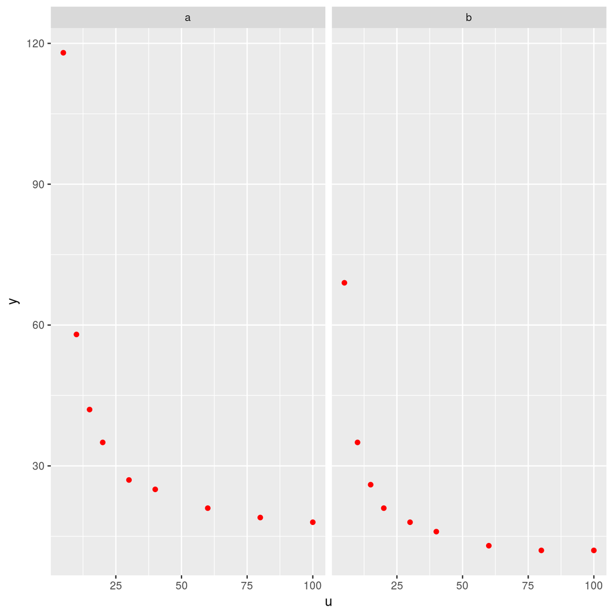

Clotting time (y) Vs. percentage concentration (u) by lot

```r
ggp <- ggplot(data = clotting, mapping = aes(x = u,y = y)) +
  geom_point(colour="red") +
  facet_wrap(facets = ~lot)
print(ggp)
```

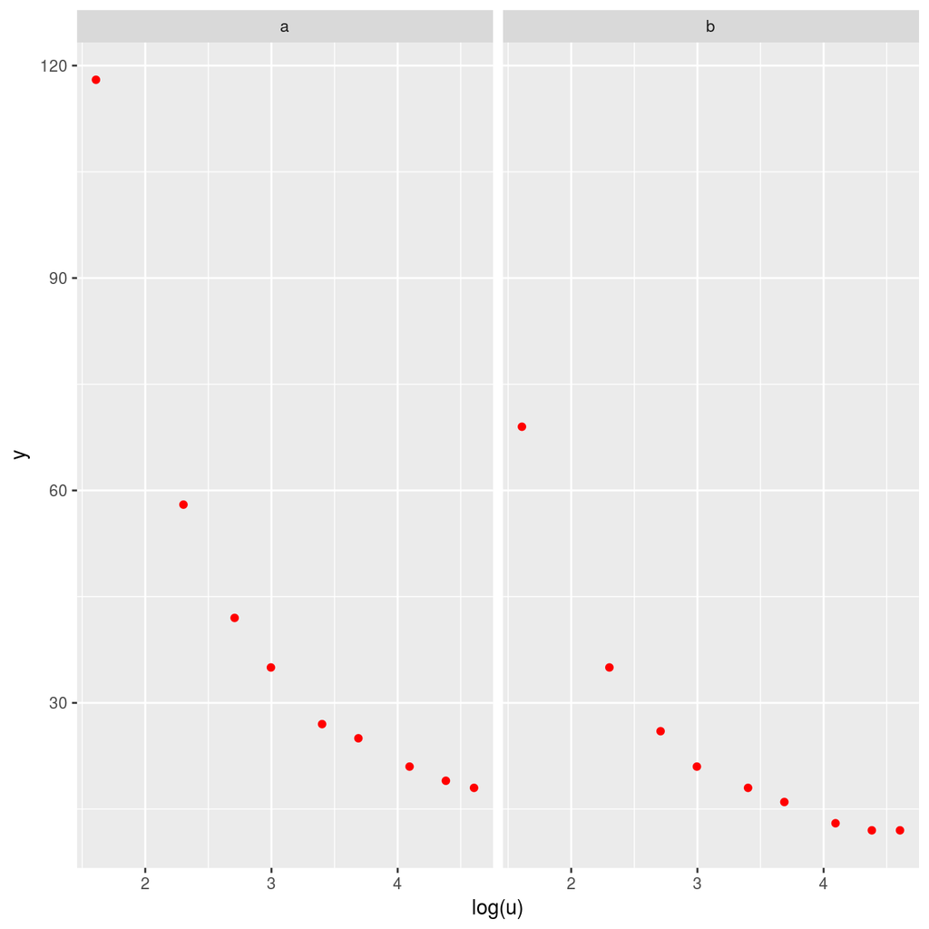

Clotting time (y) Vs. log of percentage concentration log(u) by lot

```r
ggp <- ggplot(data = clotting, mapping = aes(x = log(u),y = y)) +
  geom_point(colour="red") +
  facet_wrap(facets = ~lot)
print(ggp)
```

A clear relation between `y` and the inverse of `u` or `log(u)` exists.  
Consequently, a model with Gamma dependent variable and default link function (“inverse”, for Gamma distribution) could be effective.  
Since the analysis on the concentration of active ingredient is usuallly performed on the log of concentration, and since the relation seem more regular in `log(u)` then the model with `log(u)` will be tested

### Inference and models

Now let’s try a model with intercept only

```r
fm0 <- glm(y ~ 1, data = clotting, family = Gamma())
summary(fm0)
```

```
##
## Call:
## glm(formula = y ~ 1, family = Gamma(), data = clotting)
##
## Deviance Residuals:
##      Min        1Q    Median        3Q       Max
## -0.85506  -0.53799  -0.32925   0.07503   1.63788
##
## Coefficients:
##             Estimate Std. Error t value Pr(>|t|)
## (Intercept)  0.03077    0.00590   5.215 7.01e-05 ***
## ---
## Signif. codes:  0 '***' 0.001 '**' 0.01 '*' 0.05 '.' 0.1 ' ' 1
##
## (Dispersion parameter for Gamma family taken to be 0.661859)
##
##     Null deviance: 7.7087  on 17  degrees of freedom
## Residual deviance: 7.7087  on 17  degrees of freedom
## AIC: 158.71
##
## Number of Fisher Scoring iterations: 6
```

And now the model with `log(u)` as independent variable

```r
fm1 <- glm(y ~ log(u), data = clotting, family = Gamma())
summary(fm1)
```

```
##
## Call:
## glm(formula = y ~ log(u), family = Gamma(), data = clotting)
##
## Deviance Residuals:
##      Min        1Q    Median        3Q       Max
## -0.32178  -0.23316  -0.01691   0.19701   0.31296
##
## Coefficients:
##              Estimate Std. Error t value Pr(>|t|)
## (Intercept) -0.019635   0.004127  -4.757 0.000214 ***
## log(u)       0.018609   0.001827  10.187 2.12e-08 ***
## ---
## Signif. codes:  0 '***' 0.001 '**' 0.01 '*' 0.05 '.' 0.1 ' ' 1
##
## (Dispersion parameter for Gamma family taken to be 0.06219859)
##
##     Null deviance: 7.7087  on 17  degrees of freedom
## Residual deviance: 1.0183  on 16  degrees of freedom
## AIC: 123.17
##
## Number of Fisher Scoring iterations: 4
```

Follows the model with `log(u)` and `lot`, without interaction

```r
fm2 <- glm(y ~ log(u) + lot, data = clotting, family = Gamma())
summary(fm2)
```

```
##
## Call:
## glm(formula = y ~ log(u) + lot, family = Gamma(), data = clotting)
##
## Deviance Residuals:
##      Min        1Q    Median        3Q       Max
## -0.20734  -0.12219   0.05504   0.09440   0.22464
##
## Coefficients:
##              Estimate Std. Error t value Pr(>|t|)
## (Intercept) -0.021450   0.002187  -9.808 6.45e-08 ***
## log(u)       0.017756   0.001023  17.361 2.43e-11 ***
## lotb         0.010868   0.001950   5.574 5.32e-05 ***
## ---
## Signif. codes:  0 '***' 0.001 '**' 0.01 '*' 0.05 '.' 0.1 ' ' 1
##
## (Dispersion parameter for Gamma family taken to be 0.0195856)
##
##     Null deviance: 7.70867  on 17  degrees of freedom
## Residual deviance: 0.30042  on 15  degrees of freedom
## AIC: 103.07
##
## Number of Fisher Scoring iterations: 4
```

Finally, the model with `log(u)`, `lot` and their interaction

```r
fm3 <- glm(y ~ lot + log(u) + lot:log(u), data = clotting, family = Gamma())
summary(fm3)
```

```
##
## Call:
## glm(formula = y ~ lot + log(u) + lot:log(u), family = Gamma(),
##     data = clotting)
##
## Deviance Residuals:
##       Min         1Q     Median         3Q        Max
## -0.055738  -0.035480  -0.008216   0.026073   0.086411
##
## Coefficients:
##               Estimate Std. Error t value Pr(>|t|)
## (Intercept) -0.0165544  0.0008655 -19.127 1.97e-11 ***
## lotb        -0.0073541  0.0016780  -4.383 0.000625 ***
## log(u)       0.0153431  0.0003872  39.626 8.85e-16 ***
## lotb:log(u)  0.0082561  0.0007353  11.228 2.18e-08 ***
## ---
## Signif. codes:  0 '***' 0.001 '**' 0.01 '*' 0.05 '.' 0.1 ' ' 1
##
## (Dispersion parameter for Gamma family taken to be 0.002129707)
##
##     Null deviance: 7.708667  on 17  degrees of freedom
## Residual deviance: 0.029401  on 14  degrees of freedom
## AIC: 63.195
##
## Number of Fisher Scoring iterations: 3
```

Now a test to see if the interaction between `lot` and `log(u)` can be considered significant:

```r
anova(fm2,fm3,test="F")
```

```
## Analysis of Deviance Table
##
## Model 1: y ~ log(u) + lot
## Model 2: y ~ lot + log(u) + lot:log(u)
##   Resid. Df Resid. Dev Df Deviance      F    Pr(>F)
## 1        15   0.300421
## 2        14   0.029401  1  0.27102 127.26 2.059e-08 ***
## ---
## Signif. codes:  0 '***' 0.001 '**' 0.01 '*' 0.05 '.' 0.1 ' ' 1
```

The interaction term is significant, and then the full model is retained.  
From this model, it appears that the lot `b` (with respect lot `a`) produces an lower intercept, and then a higher value of clotting time when `log(u)` is zero, while the clotting time seems to decrease more rapidly (when `log(u)` increases) with lot `b` instead of lot `a`.

Now the plot of diagnostic graphs

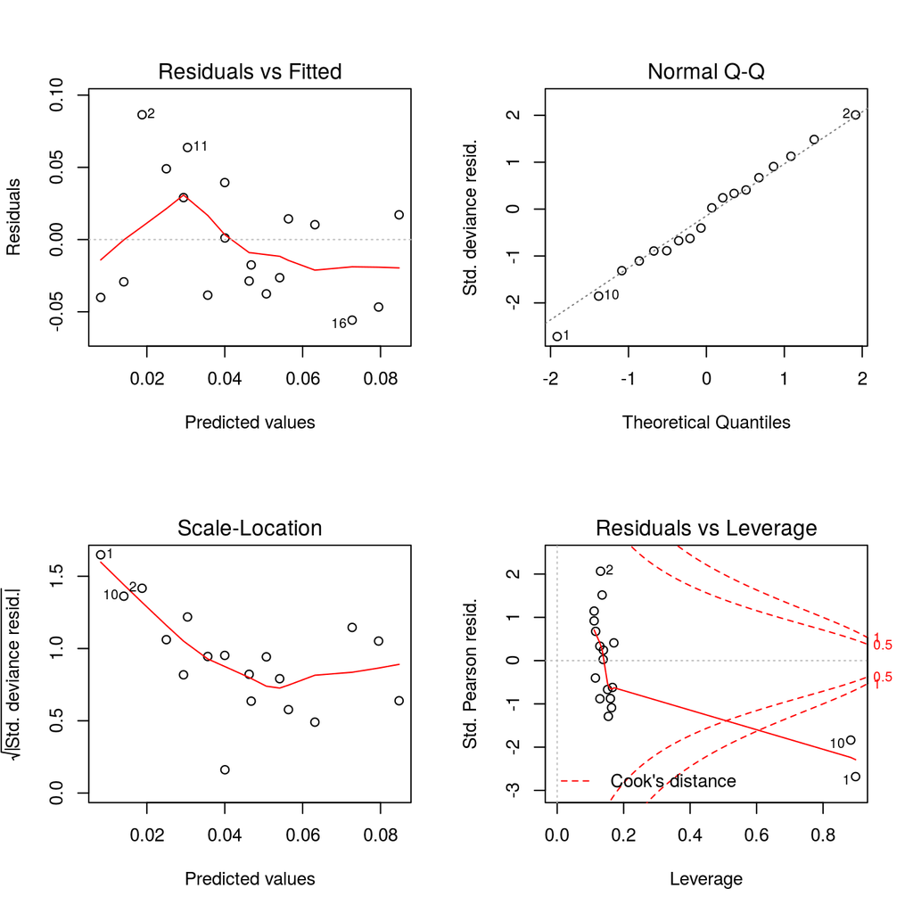

Residual plot of last model

```r
op <- par(mfrow = c(2, 2))
plot(fm3)
par(op)
```

Some little heteroscedasticity seems to appear, but globally the model seems almost good.

Now a couple of graphs to plot the estimates.

The first graph shows separately the measured data points and the estimated values of clotting time.

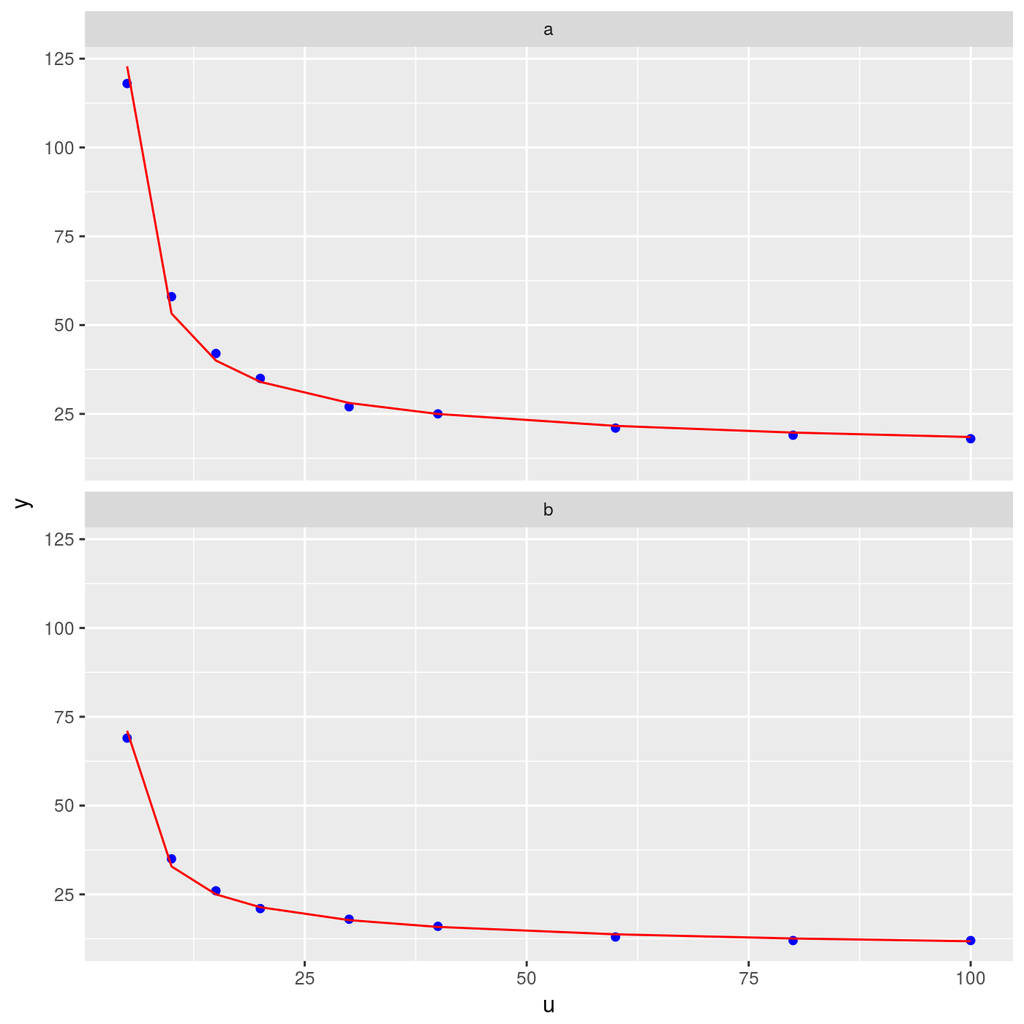

Fitted and observed by lot

```r
clotting$pred <- predict(fm3, type = "response")
clotting <- clotting %>% arrange(lot, u)
ggp <- ggplot(data=clotting, mapping = aes(x=u, y=y)) +
  geom_point(colour="blue") +
  geom_line(mapping = aes(y=pred), colour="red") +
  facet_wrap(facets = ~lot, ncol = 1)
print(ggp)
```

The second graph shows the measured data points and the estimated values of clotting time in only one plot.

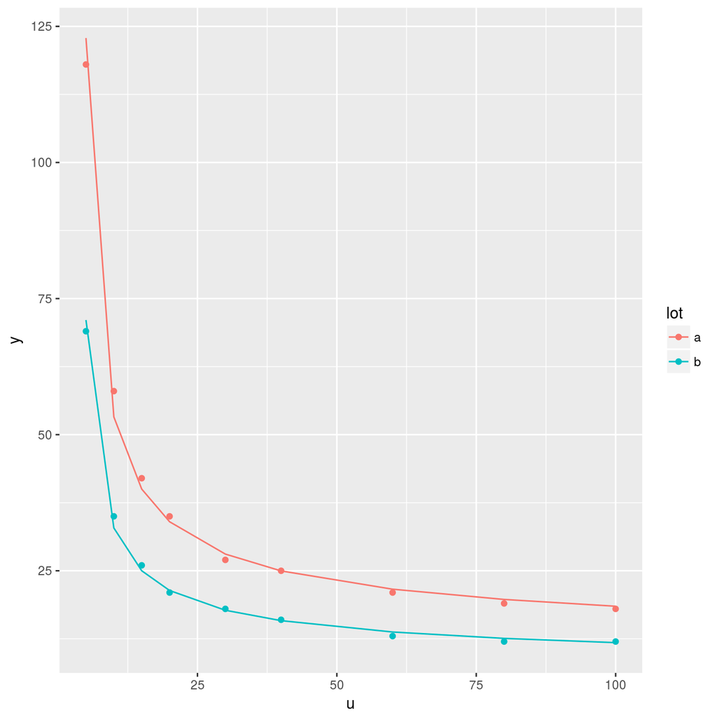

Fitted and observed by lot (colours)

```r
ggp <- ggplot(data=clotting, mapping = aes(x=u, y=y, colour=lot)) +
  geom_point() +
  geom_line(mapping = aes(y=pred))
print(ggp)
```

Previous graphs seem to “say” something different with repect to the estimated parameters, because the lot `b` curve is always less than the lot `a` one. This may be explained producing a graph on the linear scale, and “extending” the x-axis scale to values less that the current minimum (i.e., `log(5)`):

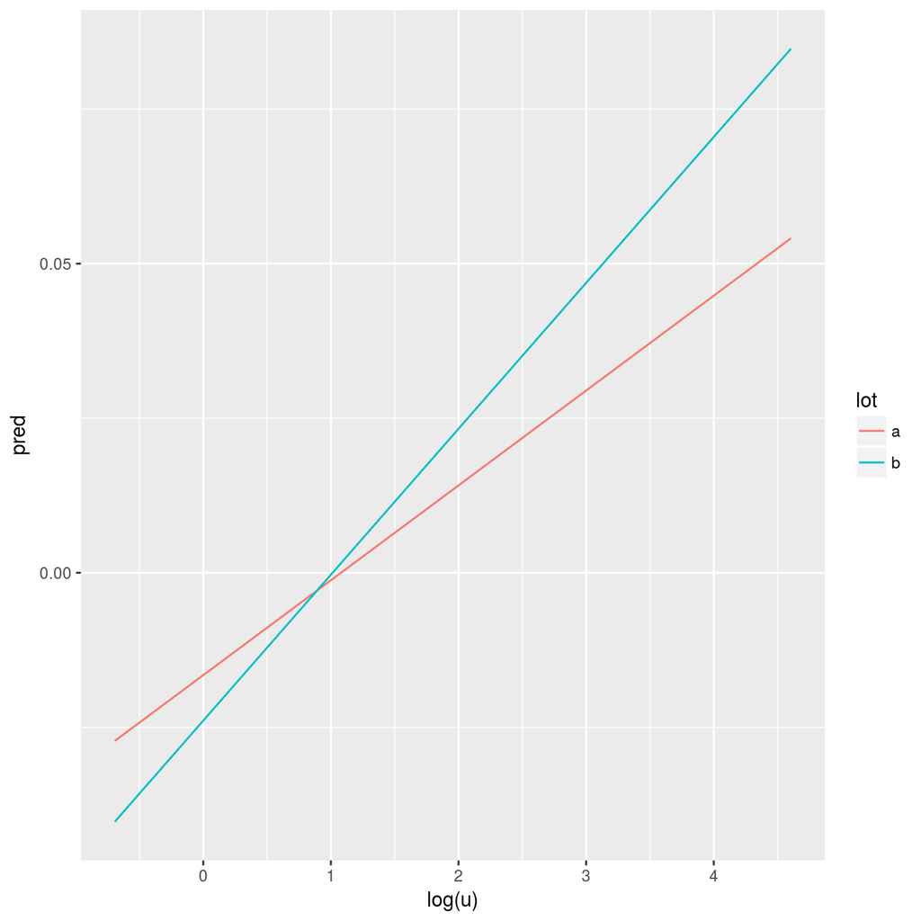

Linear component of model with extended range of x values

```r
clotting <- clotting %>% bind_rows(data.frame(u=c(.5,.5), lot=c("a","b"), y=c(NA,NA), pred=c(NA,NA)))
clotting$pred <- predict(fm3,newdata=clotting)
ggp <- ggplot(data=clotting, mapping = aes(x=log(u), y=pred, colour=lot)) +
  geom_line()
print(ggp)
```

As we can see, the linear component of model shows two crossing lines, with lot `a` one having an higher intercept and a lower slope than the lot `b` one.